# Fisheries Stablity under Environmental Change: Early Warning Signals

Fisheries stability under multiple drivers of change.

Stability is one of the tenets of food security. Also widely used objective for management. Definition of fisheries stability unclear - whether it is the ecological part of the system (stocks) or whole social-ecological system including management (Example?). Improved knowledge of how the dynamics of fisheries systems is needed to inform SDGs, specifically SDG14 (quote stablity).

The main goal of this study is to assess how useful early warning signals from catch data are to inform changes in fisheries stability and/or resilience in the face of environmetal change.

We focus on a climate-change hotspot, Southeast Australian Shelf Large Marine Ecosystem, and analyse whether there exits EWS in catch data time series (SAUP and AFMA).

We then use a trait-based modelling approach, broadly paramterised for the Southeast Australian Shelf Large Marine Ecosystem (LME 42).

At a later stage, this work will combine climate scenarios and be extended to all LMEs to investigate links within and across ocean food systems. This work is a contribution to FishMIP, co-funded by Dalhousie University and ARC.

```r
library(tidyverse)
remotes::install_github("sizespectrum/mizerExperimental")
library(mizerExperimental)
#library(mizerMR)
library(mizerHowTo)
library(tibble)
library(purrr)
library(zoo)
library(Hmisc)
library(mgcv)
library(data.table)
library(tidyverse)
library(ggpubr)
library(rvest)
library(stringr)
library(magrittr)
library(Kendall)
library(boot)
```

Theory - Critical slowing down. Based primarily on simple models although present in many types of data. What does this mean for fished ecosystems (social-ecological systems)?

PART 1. Data

Question 1) What does EWS analysis of catches show?

```r
# Read in SAUP catches instead
```

```
There were 16 warnings (use warnings() to see them)
```

```r
SAUPcatches<-read.csv("../data/SAU LME 42 v48-0/SAU LME 42 v48-0.csv")
head(SAUPcatches)
```

|  | area_name | area_type | year | scientific_name | common_name | functional_group | commercial_group | fishing_entity | fishing_sector | catch_type | reporting_status | gear_type | end_use_type | tonnes | landed_value |
| --- | --- | --- | --- | --- | --- | --- | --- | --- | --- | --- | --- | --- | --- | --- | --- |
| 1 | Southeast Australian Shelf | lme | 1950 | Marine fishes not identified | Marine fishes nei | Medium demersals (30 - 89 cm) | Other fishes & inverts | Australia | Industrial | Discards | Unreported | bottom trawl | Direct human consumption | 239.9267369 | NA |
| 2 | Southeast Australian Shelf | lme | 1950 | Marine fishes not identified | Marine fishes nei | Medium demersals (30 - 89 cm) | Other fishes & inverts | Australia | Industrial | Discards | Unreported | pelagic trawl | Direct human consumption | 9.2261932 | NA |
| 3 | Southeast Australian Shelf | lme | 1950 | Marine fishes not identified | Marine fishes nei | Medium demersals (30 - 89 cm) | Other fishes & inverts | Australia | Industrial | Landings | Reported | bottom trawl | Direct human consumption | 607.7447746 | NA |
| 4 | Southeast Australian Shelf | lme | 1950 | Marine fishes not identified | Marine fishes nei | Medium demersals (30 - 89 cm) | Other fishes & inverts | Australia | Industrial | Landings | Reported | bottom trawl | Fishmeal and fish oil | 0.3041766 | NA |
| 5 | Southeast Australian Shelf | lme | 1950 | Marine fishes not identified | Marine fishes nei | Medium demersals (30 - 89 cm) | Other fishes & inverts | Australia | Industrial | Landings | Reported | bottom trawl | Other | 0.3041766 | NA |
| 6 | Southeast Australian Shelf | lme | 1950 | Marine fishes not identified | Marine fishes nei | Medium demersals (30 - 89 cm) | Other fishes & inverts | Australia | Industrial | Landings | Reported | pelagic trawl | Direct human consumption | 6.0952145 | NA |

[figure not shown]

```r
# also from SAUP for this LME:
#LME area   1,177,870 km2
#Shelf Area 219,772 km2
#Inshore Fishing Area (IFA) 194,195 km2
#Tropical Coral Reefs   0 % of world
#Seamounts  0.168 % of world
#Primary production 514.76 mgCm-2day-1
catch_sum2<-aggregate(SAUPcatches$tonnes,list(SAUPcatches$year,SAUPcatches$functional_group),sum)
names(catch_sum2)<-c("year","functional_group","tonnes")
# Plot
ggplot(catch_sum2, aes(year, y=tonnes, fill=functional_group )) + geom_area()
```

```r
# check relative dominances of FGs in one year
c2010<-catch_sum2[catch_sum2$year==2010,]
c2010[order(c2010$tonnes,decreasing = T),]
```

|  | year | functional_group | tonnes |
| --- | --- | --- | --- |
| 958 | 2010 | Medium demersals (30 - 89 cm) | 5978.052172 |
| 1027 | 2010 | Medium pelagics (30 - 89 cm) | 5306.914697 |
| 889 | 2010 | Medium benthopelagics (30 - 89 cm) | 3530.952472 |
| 682 | 2010 | Lobsters, crabs | 2983.339508 |
| 337 | 2010 | Large demersals (>=90 cm) | 2138.103950 |
| 613 | 2010 | Large sharks (>=90 cm) | 2116.421555 |
| 268 | 2010 | Large benthopelagics (>=90 cm) | 1525.585922 |
| 1165 | 2010 | Other demersal invertebrates | 1480.186001 |
| 406 | 2010 | Large pelagics (>=90 cm) | 626.490986 |
| 1096 | 2010 | Medium reef assoc. fish (30 - 89 cm) | 569.494323 |

[output cut: 14 more lines]

```r
# extract only fishMIP FGs
unique(catch_sum2$functional_group)
```

```
 [1] "Cephalopods"
 [2] "Large bathydemersals (>=90 cm)"
 [3] "Large bathypelagics (>=90 cm)"
 [4] "Large benthopelagics (>=90 cm)"
 [5] "Large demersals (>=90 cm)"
 [6] "Large pelagics (>=90 cm)"
 [7] "Large rays (>=90 cm)"
 [8] "Large reef assoc. fish (>=90 cm)"
 [9] "Large sharks (>=90 cm)"
[10] "Lobsters, crabs"
[11] "Medium bathydemersals (30 - 89 cm)"
[12] "Medium bathypelagics (30 - 89 cm)"
[13] "Medium benthopelagics (30 - 89 cm)"
[14] "Medium demersals (30 - 89 cm)"
[15] "Medium pelagics (30 - 89 cm)"
[16] "Medium reef assoc. fish (30 - 89 cm)"
[17] "Other demersal invertebrates"
[18] "Shrimps"
[19] "Small benthopelagics (<30 cm)"
[20] "Small demersals (<30 cm)"
[21] "Small pelagics (<30 cm)"
[22] "Small reef assoc. fish (<30 cm)"
[23] "Small to medium flatfishes (<90 cm)"
[24] "Small to medium rays (<90 cm)"
[25] "Small to medium sharks (<90 cm)"
```

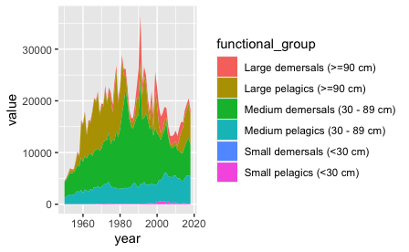

```r
#unique(effort_sum$FGroup)
#unique(effort_sum$FGroup)
#[1] "demersal<30cm"   "demersal>=90cm"  "demersal30-90cm"
#[4] "pelagic<30cm"    "pelagic>=90cm"   "pelagic30-90cm"
fishmip_groups<-c("Small demersals (<30 cm)","Medium demersals (30 - 89 cm)",
"Large demersals (>=90 cm)",
"Small pelagics (<30 cm)",
"Medium pelagics (30 - 89 cm)",
"Large pelagics (>=90 cm)")
catch<-filter(catch_sum2, functional_group %in% fishmip_groups)
names(catch)[3]<-"value"
# Plot
ggplot(catch, aes(year, y=value, fill=functional_group )) + geom_area()
```

Function to run the EWS metrics.

```r
runEWS<-function(results=results) {
```

```
There were 16 warnings (use warnings() to see them)
```

```r
 window <- c(0.3, 0.4,0.5, 0.6,0.7)
for(i in window){

  assign(paste0("window", i),
    results %>%
    group_by(year) %>%
    summarise(value=sum(value)) %>%
    mutate(Normalized_value = (value - mean(value))/sd(value)) %>%
    mutate(log_Value = log10(value)) %>%
    #mutate(Element="Fisheries") %>%
    mutate(Differenced = (resid(gam(value~s(year))))) %>% #diag(1:4)
  #  mutate(Differenced = c(0, diff(value))) %>% ### fit a gam value smoothed by year and then get residuals and then run everything below, call it Difference
    mutate(Variance = rollapply(data = Differenced,
                                width = i*length(Differenced),
                                FUN = sd,
                                align = "right",
                                fill = NA,
                                na.rm = T)) %>%
    mutate(Mean = rollapply(data = Differenced,
                            width = i*length(Differenced),
                            FUN = mean,
                            align = "right",
                            fill = NA,
                            na.rm = T)) %>%
   # mutate(CV=Variance/Mean) %>%
    mutate(AR1 = rollapply(data = (Differenced),
                           width = i*length(Differenced),
                           FUN = function(z,  na.rm = FALSE){
                             return(acf(z, plot=FALSE)$acf[2])
                           },
                           align = "right",
                           fill = NA,
                           na.rm = T)) %>%
    mutate(Return_rate = rollapply(data=Differenced,
                                   width= i*length(Differenced),
                                   FUN = function(z, na.rm=FALSE){
                                     ar1 <- ar.ols(z,demean=FALSE, order.max = 1, aic = FALSE, intercept = FALSE)
                                     return(return_rate = 1/ar1$ar[1])
                                   },
                                   align = "right",
                                   fill = NA,
                                   na.rm = T)) %>%
    mutate(Kurtosis = rollapply(data=Differenced,
                                   width=i*length(Differenced),
                                   FUN = moments::kurtosis,
                                   align = "right",
                                   fill = NA,
                                   na.rm = T)) %>%
    mutate(Skewness = rollapply(data=Differenced,
                                   width=i*length(Differenced),
                                   FUN = moments::skewness,
                                   align = "right",
                                   fill = NA,
                                   na.rm = T)) %>%
    mutate(Width = i)%>%
    # still good. used to create a composite metric
    mutate(Diff_AR1= rollapply(data = Differenced,
                           width =i* length(Differenced),
                           FUN = function(z,  na.rm = FALSE){
                             return(acf(z, plot=FALSE)$acf[2])
                           },
                           align = "right",
                           fill = NA,
                           na.rm = T)))

}
#fisheries <- bind_rows(window0.3, window0.4, window0.5, window0.6,window0.7)
fisheries <- bind_rows(window0.3, window0.4, window0.5, window0.6,window0.7)
fisheries
}
fisheries<-runEWS(results=catch)
```

Plot the times series of the data.

```r
plot_EWS<-function(fisheries=fisheries,start=1950,end=2020){
```

```
There were 16 warnings (use warnings() to see them)
```

```
Removed 19 row(s) containing missing values (geom_path).Removed 19 row(s) containing missing values (geom_path).
```

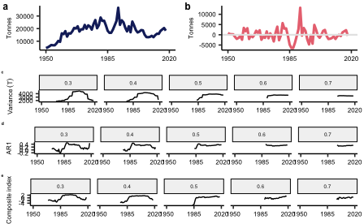

```r
landings <- ggplot(fisheries %>% filter(Width ==0.5), aes(x=year)) +
geom_line(aes(y=value), colour="#172869", size=1.1)+
theme_pubr()+
theme(text = element_text(size=6),axis.title.x = element_blank())+
scale_x_continuous(breaks=c(start,(start+end)/2,end), labels = c(start,(start+end)/2,end), limits = c(start,end))+
labs(y=bquote(Tonnes))
residuals <- ggplot(fisheries %>% filter(Width ==0.5),
       aes(x=year)) +
geom_line(aes(y=Differenced), colour="#EA7580", size=1.1)+
theme_pubr()+
theme(text = element_text(size=6),axis.title.x = element_blank())+
scale_x_continuous(breaks=c(start,(start+end)/2,end), labels = c(start,(start+end)/2,end), limits = c(start,end))+geom_hline(yintercept = 0, linetype=1, colour="grey90", size=0.75)+
labs(y=bquote(Tonnes))

variance_ts <- fisheries$Variance[!is.na(fisheries$Variance)]
# trend in Variance - positive then increase in variance
 (variance_tau <- Kendall(1:length(variance_ts), variance_ts)$tau[1])
 tau.fc<-function(x,y){
    y<-sample(x, replace = T)
   tau<-as.numeric(Kendall(1:length(y), y)$tau)
   return(tau)
 }
#reliability investigation into trend test
  vars <- ggplot(data=fisheries, aes(x=year, y=Variance))+
    geom_line()+
    facet_grid(.~Width)+
    theme_pubr()+
      theme(
        text = element_text(size=6),
        axis.title.x = element_blank()
      )+
      scale_x_continuous(breaks=c(start,(start+end)/2,end), labels = c(start,(start+end)/2,end), limits = c(start,end))+
      labs(y=bquote(Variance~(T)))


  ar1 <- ggplot(data=fisheries, aes(x=year, y=AR1))+
    geom_line()+
    facet_grid(.~Width)+
    theme_pubr()+
      theme(
        text = element_text(size=6),
        axis.title.x = element_blank()
      )+
   scale_x_continuous(breaks=c(start,(start+end)/2,end), labels = c(start,(start+end)/2,end), limits = c(start,end))+
      labs(y="AR1", x="Year")

  # add compposite metrics form Chris's paper:

  comp_fisheries <- fisheries %>%
    drop_na() %>%
    group_by(Width) %>%
    nest() %>%
    mutate(Normalised_variance = map(data, ~((.$Variance-mean(.$Variance))/sd(.$Variance))),
           Normalised_AR = map(data, ~((.$AR1-mean(.$AR1))/sd(.$AR1)))) %>%
    unnest(cols = c(data, Normalised_variance, Normalised_AR)) %>%
    mutate(Composite_index = Normalised_variance+Normalised_AR)


   comp_index <- ggplot(data=comp_fisheries, aes(x=year, y=Composite_index))+
    geom_line()+
    facet_grid(.~Width)+
    theme_pubr()+
      theme(
        text = element_text(size=6),
        axis.title.x = element_blank()
      )+
     scale_x_continuous(breaks=c(start,(start+end)/2,end), labels = c(start,(start+end)/2,end), limits = c(start,end))+
      labs(y=bquote(Composite~index))

   landings_residuals <- ggarrange(landings, residuals,
          labels = c("a", "b"),
          font.label = list(size=9),
          ncol = 2,
          nrow = 1)

   ggarrange(landings_residuals, vars,ar1, comp_index,
           nrow=4, ncol=1,
           labels = c("", "c", "d", "e"),
           font.label = list(size=4),
           heights = c(1,0.75,0.75,0.75))

#st_dev <- sd((fisheries %>% #filter(Width==0.5))$Differenced)

#bds.test((fisheries %>% filter(Width==0.5))$Differenced, eps = c(0.5*st_dev, 0.75*st_dev, 1*st_dev))
#fisheries_test <- fisheries %>% filter(Width==0.5)
#qqnorm((fisheries_test$Differenced[2:68]))
#qqline(fisheries_test$Differenced[2:68])

          }

plot_EWS(fisheries)
```

PART 2:

Now set up a mizer model with these functional groups. Will add multiple resources (bethic and pelagic) later.

```r
# check if start  from scratch
speciesParams<-read.csv("../data/fg_params.csv")
inter<-read.csv("../data/inter.csv")[,-1]
params <- newMultispeciesParams(speciesParams, kappa = 1e9,inter)
```

```
Note: Dimnames of interaction matrix do not match the order of species names in the species data.frame. I am now ignoring your dimnames so your interaction matrix may be in the wrong order.
No ks column so calculating from critical feeding level.
Using z0 = z0pre * w_inf ^ z0exp for missing z0 values.
```

```r
species_params(params)$R_max<-species_params(params)$R_max<-params@resource_params$kappa*params@species_params$w_inf^-1
species_params(params)$erepro<-0.0001
species_params(params)$h<-40
sim<- project(params, t_max = 200, effort = 0)
```

[output not shown]

[output cut: 56 more lines]

[output not shown]

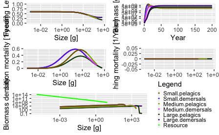

```r
plot(sim)
```

```r
#tuneParams(params) - made adjustments to kappa in tueParams and saved file below:
 # params<-readRDS("../data/params.rds")
 # sim<- project(params, t_max = 200, effort = 0)
 # plot(sim)
#tuneGrowth(params)
#idealy would have calibrated model to catch time series.. do later, for now consider as a general trait-based model.
# by default mizer sets up a gear_params object
params@gear_params
```

|  | species | gear | sel_func | knife_edge_size | catchability |
| --- | --- | --- | --- | --- | --- |
| Small.pelagics, knife_edge_gear | Small.pelagics | knife_edge_gear | knife_edge | 67.5 | 1 |
| Small.demersals, knife_edge_gear | Small.demersals | knife_edge_gear | knife_edge | 67.5 | 1 |
| Medium.pelagics, knife_edge_gear | Medium.pelagics | knife_edge_gear | knife_edge | 540.0 | 1 |
| Medium.demersals, knife_edge_gear | Medium.demersals | knife_edge_gear | knife_edge | 540.0 | 1 |
| Large.pelagics, knife_edge_gear | Large.pelagics | knife_edge_gear | knife_edge | 1822.5 | 1 |
| Large.demersals, knife_edge_gear | Large.demersals | knife_edge_gear | knife_edge | 1822.5 | 1 |

```r
# when effort is set  to > 0 the fishing gets switched on
# have a look:
sim_f<- project(params, t_max = 200, effort = 0.2)
```

[output not shown]

[output cut: 54 more lines]

[output not shown]

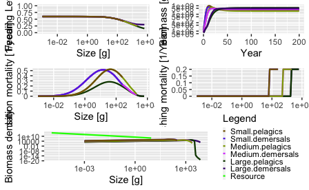

```r
plot(sim_f)
```

[output not shown]

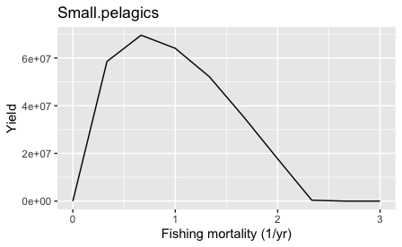

```r
# check yield curves
#plotFmsy(params)
plotYieldVsF(params,species="Small.pelagics")
```

[output not shown]

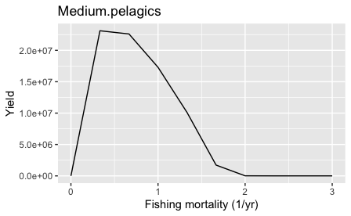

```r
plotYieldVsF(params,species="Medium.pelagics")
```

[output not shown]

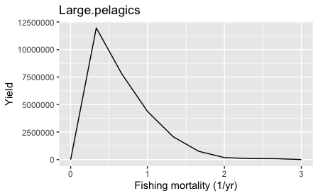

```r
plotYieldVsF(params,species="Large.pelagics")
```

Now set up effort through time

```r
# set up fishing moratlity (here called effort) time series
```

```
There were 16 warnings (use warnings() to see them)
```

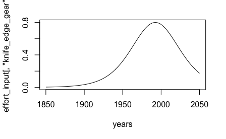

```r
years<-1850:2050
species<-speciesParams$species
gear<-"knife_edge_gear"
#effort_input<-matrix(0,nrow=201,ncol=6,dimnames = list(years,species))
effort_input<-matrix(0,nrow=201,ncol=1,dimnames = list(years,gear))
row.names(matrix)
# Historical effort (here we use fishing mortality rate, could separate catchabilty and effort later)
# Use double logistic curve (fishing mortality through time), with a descending limb
# starting from 1850
# f(y) ~ F/(1+ exp(-y0(y-y1))) * F/(1 + exp(-y2(y-y3))
# where:
# y1, the year value of the sigmoid's midpoint;
# F, the curve's maximum value;
# k, the logistic growth rate or steepness of the curve
c1=0.05
c2=0.05 # 0.1 fast, 0.03 medium-MSY, 0.01 slow
yr50a=1980
yr50b=2005
Fmax1=1
Fmax2=1
effort_input[,"knife_edge_gear"]<-(Fmax1/(1+ exp(-c1*(years-yr50a))))*(Fmax2/(1 + exp(c2*(years-yr50b))))
#transform
effort_input<-effort_input/max(effort_input)*0.8
plot(years,effort_input[,"knife_edge_gear"],typ="l")
```

```r
simt <- project(params, effort = effort_input,initial_n = sim@n[200,,], initial_npp = sim@n[200,])
```

[output not shown]

[output cut: 56 more lines]

[output not shown]

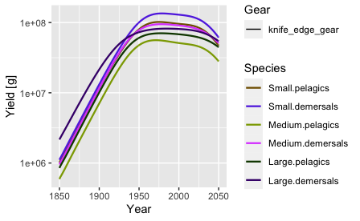

```r
# Each species yields through time
plotYieldGear(simt)
```

### Adding noise to the resource through time

We add noise to the resource function. To prepare for random changes in plankton carrying capacity every half year,we create an environment to maintain state between function calls.

```r
plankton_state <- new.env(parent = emptyenv())
plankton_state$time <- 0
plankton_state$factor <- 1
plankton_state$phi <- 0
plankton_state$sigma <- 0.8
resource_semichemostat_noise<-function (params, n, n_pp, n_other, rates, t, dt, resource_rate, resource_capacity, ...)
{  plankton_state$time <- plankton_state$time + dt
   # red noise
   plankton_state$factor <- plankton_state$factor ^ plankton_state$phi*exp(rnorm(1, 0, plankton_state$sigma))
   # plankton_state$factor <- exp(runif(1, log(1/2), log(2)))
    mur <- resource_rate + rates$resource_mort
    n_steady <- resource_rate * resource_capacity/plankton_state$factor/mur
   #  n_steady <- resource_rate * resource_capacity/exp(runif(1, log(1/2), log(2)))/mur
    n_pp_new <- n_steady + (n_pp - n_steady) * exp(-mur * dt)
    sel <- mur == 0
    n_pp_new[sel] <- n_pp[sel]
    n_pp_new
}
```

```
There were 16 warnings (use warnings() to see them)
```

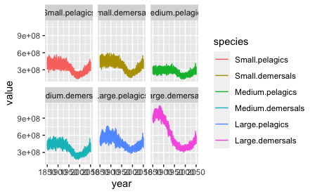

```r
ggplot(results[results$variable=="biomass",], aes(year, y=value, color=species )) + geom_line() + facet_wrap(vars(species))
```

```
Removed 59 row(s) containing missing values (geom_path).Removed 59 row(s) containing missing values (geom_path).
```

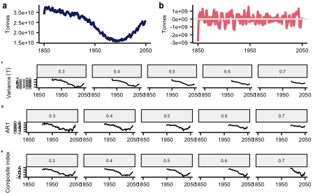

```r
fisheries_mod_bio<-runEWS(results[results$var=="biomass",])
fisheries_mod_yield<-runEWS(results[results$var=="yield",])
plot_EWS(fisheries_mod_bio,start=1850,end=2050)
```

```
Removed 59 row(s) containing missing values (geom_path).Removed 59 row(s) containing missing values (geom_path).
```

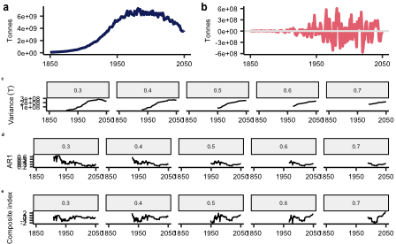

```r
plot_EWS(fisheries_mod_yield,start=1850,end=2050)
```

```r
Brel_ref <- Brel_scen  %>% mutate(collapsed = value < 0.1)
```

[output not shown]

What can we say about ecological and fisheries stability using EWS simply based on the catch?

Need to know year of collapse for each run.

Then when transitions detected.

Need to enable noise to be varied above and vary the rate of fishing development ...

We can see this causes variability in the times series - which is what we want.

Simply ask is variance rising - and how does biomass and catch look? - and does it decline when management kicks in ? 3 scenarios? Add polygons for stoch simulations

[output not shown]

landings <- ggplot(fisheries %>% filter(Width ==0.5), aes(x=year)) + geom_line(aes(y=value), colour="#172869", size=1.1)+ theme_pubr()+ theme( text = element_text(size=9), axis.title.x = element_blank())+ scale_x_continuous(breaks=c(1960,1980,2000,2020), labels = c("1960","1980","2000","2020"), limits = c(1950,2020))+ labs(y=bquote(Tonnes))

residuals <- ggplot(fisheries %>% filter(Width ==0.5), aes(x=year)) + geom_line(aes(y=Differenced), colour="#EA7580", size=1.1)+ theme_pubr()+ theme( text = element_text(size=9), axis.title.x = element_blank() )+ geom_hline(yintercept = 0, linetype=1, colour="grey90", size=0.75)+ scale_x_continuous(breaks=c(1960,1980,2000,2020), labels = c("1960","1980","2000","2020"), limits = c(1950,2020))+ labs(y=bquote(Tonnes))

landings_residuals <- ggarrange(landings, residuals, labels = c("a", "b"), font.label = list(size=9), ncol = 2, nrow = 1)